# Selection

## Model selection

In a given regression situation, there are often many choices to be made. Recall our usual setup $$ Y_{n \times 1} = X_{n \times p} \beta_{p \times 1} + \epsilon_{n \times 1}. $$

Any *subset $A \subset \{1, \dots, p\}$* yields a new regression model $$ {\cal M}(A): Y_{n \times 1} = X[,A] \beta[A] + \epsilon_{n \times 1} $$ by setting $\beta[A^c]=0$.

**Model selection** is, roughly speaking, how to choose $A$ among the $2^p$ possible choices.

```r
options(repr.plot.width=5, repr.plot.height=5)
```

### Election data

Here is a dataset from the book that we will use to explore different model selection approaches.

| Variable | Description |
| --- | --- |
| $V$ | votes for a presidential candidate |
| $I$ | are they incumbent? |
| $D$ | Democrat or Republican incumbent? |
| $W$ | wartime election? |
| $G$ | GDP growth rate in election year |
| $P$ | (absolute) GDP deflator growth rate |
| $N$ | number of quarters in which GDP growth rate $> 3.2\%$ |

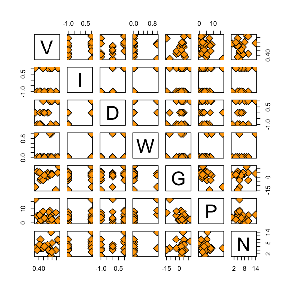

```r
url = 'http://stats191.stanford.edu/data/election.table'
election.table = read.table(url, header=T)
pairs(election.table[,2:ncol(election.table)], cex.labels=3, pch=23,
      bg='orange', cex=2)
```

## Problem & Goals

- When we have many predictors (with many possible interactions), it can be difficult to find a good model.
- Which main effects do we include?
- Which interactions do we include?
- Model selection procedures try to *simplify / automate* this task.
- Election data has $2^6=64$ different models with just main effects!

## General comments

- This is generally an "unsolved" problem in statistics: there are no magic procedures to get you the "best model."
- Many machine learning methods look for good "sparse" models: selecting a "sparse" model.
- "Machine learning" often work with very many predictors.
- Our model selection problem is generally at a much smaller scale than "data mining" problems.
- Still, it is a hard problem.
- **Inference after selection is full of pitfalls!**

## Hypothetical example

- Suppose we fit a a model $F: \quad Y_{n \times 1} = X_{n \times p} \beta_{p \times 1} + \varepsilon_{n \times 1}$ with predictors ${ X}_1, \dots, { X}_p$.
- In reality, some of the $\beta$’s may be zero. Let’s suppose that $\beta_{j+1}= \dots= \beta_{p}=0$.
- Then, any model that includes $\beta_0, \dots, \beta_j$ is *correct*: which model gives the *best* estimates of $\beta_0, \dots, \beta_j$?
- Principle of *parsimony* (i.e. Occam’s razor) says that the model with *only* ${X}_1, \dots, {X}_j$ is "best".

## Justifying parsimony

- For simplicity, let’s assume that $j=1$ so there is only one coefficient to estimate.
- Then, because each model gives an *unbiased* estimate of $\beta_1$ we can compare models based on $\text{Var}(\widehat{\beta}_1).$
- The best model, in terms of this variance, is the one containing only ${ X}_1$.
- What if we didn’t know that only $\beta_1$ was non-zero (which we don’t know in general)?
- In this situation, we must choose a set of variables.

## Model selection: choosing a subset of variables

- To "implement" a model selection procedure, we first need a criterion or benchmark to compare two models.
- Given a criterion, we also need a search strategy.
- With a limited number of predictors, it is possible to search all possible models (`leaps` in `R`).

## Candidate criteria

Possible criteria:

- $R^2$: not a good criterion. Always increase with model size $\implies$ "optimum" is to take the biggest model.
- Adjusted $R^2$: better. It "penalized" bigger models. Follows principle of parsimony / Occam’s razor.
- Mallow’s $C_p$ – attempts to estimate a model’s predictive power, i.e. the power to predict a new observation.

### Best subsets, $R^2$

Leaps takes a design matrix as argument: throw away the intercept column or leaps will complain.

```r
election.lm = lm(V ~ I + D + W + G:I + P + N, election.table)
election.lm
```

```
Call:
lm(formula = V ~ I + D + W + G:I + P + N, data = election.table)

Coefficients:
(Intercept)            I            D            W            P            N
  0.5111627   -0.0201077    0.0546159    0.0133905   -0.0007224   -0.0051822
        I:G
  0.0096901
```

```r
X = model.matrix(election.lm)[,-1]
library(leaps)
election.leaps = leaps(X, election.table$V, nbest=3, method='r2')
best.model.r2 = election.leaps$which[which((election.leaps$r2 ==
                                            max(election.leaps$r2))),]
best.model.r2
```

**1**

TRUE

**2**

TRUE

**3**

TRUE

**4**

TRUE

**5**

TRUE

**6**

TRUE

Let's plot the $R^2$ as a function of the model size. We see that the full model does include all variables.

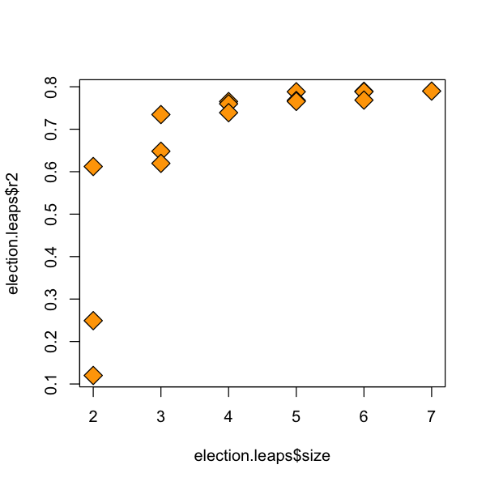

```r
plot(election.leaps$size, election.leaps$r2, pch=23, bg='orange', cex=2)
```

## Best subsets, adjusted $R^2$

- As we add more and more variables to the model – even random ones, $R^2$ will increase to 1.
- Adjusted $R^2$ tries to take this into account by replacing sums of squares by *mean squares* $$R^2_a = 1 - \frac{SSE/(n-p-1)}{SST/(n-1)} = 1 - \frac{MSE}{MST}.$$

```r
election.leaps = leaps(X, election.table$V, nbest=3, method='adjr2')
best.model.adjr2 = election.leaps$which[which((election.leaps$adjr2 == max(election.leaps$adjr2))),]
best.model.adjr2
```

**1**

TRUE

**2**

TRUE

**3**

FALSE

**4**

FALSE

**5**

TRUE

**6**

TRUE

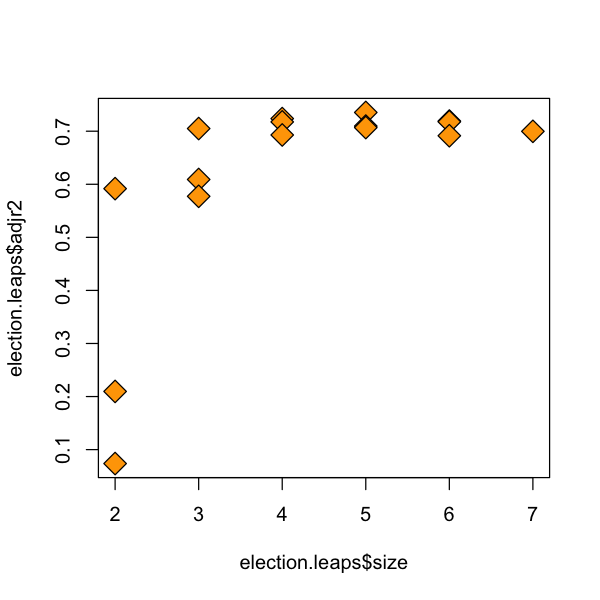

```r
plot(election.leaps$size, election.leaps$adjr2, pch=23, bg='orange',
     cex=2)
```

### Mallow’s $C_p$

- $C_p({\cal M}) = \frac{SSE({\cal M})}{\widehat{\sigma}^2} + 2 \cdot p({\cal M}) - n.$
- $\widehat{\sigma}^2=SSE(F)/df_F$ is the "best" estimate of $\sigma^2$ we have (use the fullest model), i.e. in the election data it uses all 6 main effects.
- $SSE({\cal M})$ is the $SSE$ of the model ${\cal M}$.
- $p({\cal M})$ is the number of predictors in ${\cal M}$.
- This is an estimate of the expected mean-squared error of $\widehat{Y}({\cal M})$, it takes *bias* and *variance* into account.

```r
election.leaps = leaps(X, election.table$V, nbest=3, method='Cp')
best.model.Cp = election.leaps$which[which((election.leaps$Cp ==
                                            min(election.leaps$Cp))),]
best.model.Cp
```

**1**

FALSE

**2**

TRUE

**3**

FALSE

**4**

FALSE

**5**

TRUE

**6**

TRUE

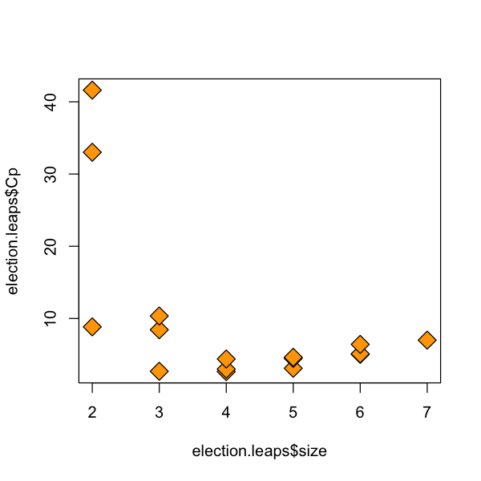

```r
plot(election.leaps$size, election.leaps$Cp, pch=23, bg='orange', cex=2)
```

## Search strategies

- Given a criterion, we now have to decide how we are going to search through the possible models.
- "Best subset": search all possible models and take the one with highest $R^2_a$ or lowest $C_p$ leaps. Such searches are typically feasible only up to $p=30$ or $40$ at the very most.
- Stepwise (forward, backward or both): useful when the number of predictors is large. Choose an initial model and be "greedy".
- "Greedy" means always take the biggest jump (up or down) in your selected criterion.

### Implementations in `R`

- "Best subset": use the function `leaps`. Works only for multiple linear regression models.
- Stepwise: use the function `step`. Works for any model with Akaike Information Criterion (AIC). In multiple linear regression, AIC is (almost) a linear function of $C_p$.

### Akaike / Bayes Information Criterion

- Akaike (AIC) defined as $$AIC({\cal M}) = - 2 \log L({\cal M}) + 2 \cdot p({\cal M})$$ where $L({\cal M})$ is the maximized likelihood of the model.
- Bayes (BIC) defined as $$BIC({\cal M}) = - 2 \log L({\cal M}) + \log n \cdot p({\cal M})$$
- Strategy can be used for whenever we have a likelihood, so this generalizes to many statistical models.

### AIC for regression

- In linear regression with unknown $\sigma^2$ $$-2 \log L({\cal M}) = n \log(2\pi \widehat{\sigma}^2_{MLE}) + n$$ where $\widehat{\sigma}^2_{MLE} = \frac{1}{n} SSE(\widehat{\beta})$
- In linear regression with known $\sigma^2$ $$-2 \log L({\cal M}) = n \log(2\pi \sigma^2) + \frac{1}{\sigma^2} SSE(\widehat{\beta})$$ so AIC is very much like Mallow’s $C_p$ in this case.

```r
n = nrow(X)
p = 7 + 1
c(n * log(2*pi*sum(resid(election.lm)^2)/n) + n + 2*p, AIC(election.lm))
```

1. -66.9402570721455

2. -66.9402570721455

### Properties of AIC / BIC

- BIC will typically choose a model as small or smaller than AIC (if using the same search direction).
- As our sample size grows, under some assumptions, it can be shown that
  - AIC will (asymptotically) always choose a model that contains the true model, i.e. it won’t leave any variables out.
  - BIC will (asymptotically) choose exactly the right model.

### Election example

Let's take a look at `step` in action. Probably the simplest strategy is *forward stepwise* which tries to add one variable at a time, as long as it can find a resulting model whose AIC is better than its current position.

When it can make no further additions, it terminates.

```r
election.step.forward = step(lm(V ~ 1, election.table),
                             list(upper = ~ I + D + W + G + G:I + P + N),
                             direction='forward',
                             k=2, trace=FALSE)
election.step.forward
```

```
Call:
lm(formula = V ~ D + P, data = election.table)

Coefficients:
(Intercept)            D            P
   0.514022     0.043134    -0.006017
```

```r
summary(election.step.forward)
```

```
Call:
lm(formula = V ~ D + P, data = election.table)

Residuals:
      Min        1Q    Median        3Q       Max
-0.101121 -0.036838 -0.006987  0.019029  0.163250

Coefficients:
             Estimate Std. Error t value Pr(>|t|)
(Intercept)  0.514022   0.022793  22.552  1.2e-14 ***
D            0.043134   0.017381   2.482   0.0232 *
P           -0.006017   0.003891  -1.546   0.1394
---
Signif. codes:  0 ‘***’ 0.001 ‘**’ 0.01 ‘*’ 0.05 ‘.’ 0.1 ‘ ’ 1

Residual standard error: 0.06442 on 18 degrees of freedom
Multiple R-squared:  0.3372,	Adjusted R-squared:  0.2636
F-statistic: 4.579 on 2 and 18 DF,  p-value: 0.02468
```

## Interactions and hierarchy

We notice that although the *full* model we gave it had the interaction `I:G`, the function `step` never tried to use it. This is due to some rules implemented in `step` that do not include an interaction unless both main effects are already in the model. In this case, because neither $I$ nor $G$ were added, the interaction was never considered.

In the `leaps` example, we gave the function the design matrix and it did not have to consider interactions: they were already encoded in the design matrix.

### BIC example

The only difference between AIC and BIC is the price paid per variable. This is the argument `k` to `step`. By default `k=2` and for BIC we set `k=log(n)`. If we set `k=0` it will always add variables.

```r
election.step.forward.BIC = step(lm(V ~ 1, election.table),
                                 list(upper = ~ I + D + W +G:I + P + N),
                                 direction='forward', k=log(nrow(X)))
```

```
Start:  AIC=-106.73
V ~ 1

       Df Sum of Sq      RSS     AIC
+ D     1 0.0280805 0.084616 -109.71
<none>              0.112696 -106.73
+ I     1 0.0135288 0.099167 -106.38
+ P     1 0.0124463 0.100250 -106.15
+ N     1 0.0024246 0.110271 -104.15
+ W     1 0.0009518 0.111744 -103.87

Step:  AIC=-109.71
V ~ D

       Df Sum of Sq      RSS     AIC
<none>              0.084616 -109.71
+ P     1 0.0099223 0.074693 -109.28
+ W     1 0.0068141 0.077801 -108.43
+ I     1 0.0012874 0.083328 -106.99
+ N     1 0.0000033 0.084612 -106.67
```

```r
summary(election.step.forward.BIC)
```

```
Call:
lm(formula = V ~ D, data = election.table)

Residuals:
      Min        1Q    Median        3Q       Max
-0.125196 -0.033002 -0.007789  0.018511  0.150298

Coefficients:
            Estimate Std. Error t value Pr(>|t|)
(Intercept)  0.48640    0.01466  33.172   <2e-16 ***
D            0.04509    0.01796   2.511   0.0212 *
---
Signif. codes:  0 ‘***’ 0.001 ‘**’ 0.01 ‘*’ 0.05 ‘.’ 0.1 ‘ ’ 1

Residual standard error: 0.06673 on 19 degrees of freedom
Multiple R-squared:  0.2492,	Adjusted R-squared:  0.2097
F-statistic: 6.305 on 1 and 19 DF,  p-value: 0.02124
```

### Backward selection

Just for fun, let's consider backwards stepwise. This starts at a full model and tries to delete variables.

There is also a `direction="both"` option.

```r
election.step.backward = step(election.lm, direction='backward')
```

```
Start:  AIC=-128.54
V ~ I + D + W + G:I + P + N

       Df Sum of Sq      RSS     AIC
- P     1  0.000055 0.023741 -130.49
- W     1  0.000170 0.023855 -130.39
<none>              0.023686 -128.54
- N     1  0.003133 0.026818 -127.93
- D     1  0.011926 0.035612 -121.97
- I:G   1  0.050640 0.074325 -106.52

Step:  AIC=-130.49
V ~ I + D + W + N + I:G

       Df Sum of Sq      RSS     AIC
- W     1  0.000120 0.023860 -132.38
<none>              0.023741 -130.49
- N     1  0.003281 0.027021 -129.77
- D     1  0.013983 0.037724 -122.76
- I:G   1  0.053507 0.077248 -107.71

Step:  AIC=-132.38
V ~ I + D + N + I:G

       Df Sum of Sq      RSS     AIC
<none>              0.023860 -132.38
- N     1  0.003199 0.027059 -131.74
- D     1  0.013867 0.037727 -124.76
- I:G   1  0.059452 0.083312 -108.12
```

```r
summary(election.step.backward)
```

```
Call:
lm(formula = V ~ I + D + N + I:G, data = election.table)

Residuals:
      Min        1Q    Median        3Q       Max
-0.043509 -0.019208 -0.004912  0.009626  0.090627

Coefficients:
             Estimate Std. Error t value Pr(>|t|)
(Intercept)  0.506530   0.020689  24.483 4.15e-14 ***
I           -0.019417   0.014701  -1.321  0.20515
D            0.055436   0.018180   3.049  0.00765 **
N           -0.004653   0.003177  -1.465  0.16241
I:G          0.009588   0.001519   6.314 1.03e-05 ***
---
Signif. codes:  0 ‘***’ 0.001 ‘**’ 0.01 ‘*’ 0.05 ‘.’ 0.1 ‘ ’ 1

Residual standard error: 0.03862 on 16 degrees of freedom
Multiple R-squared:  0.7883,	Adjusted R-squared:  0.7353
F-statistic: 14.89 on 4 and 16 DF,  p-value: 2.95e-05
```

## Cross-validation

Yet another model selection criterion is $K$-fold cross-validation.

- Fix a model ${\cal M}$. Break data set into $K$ approximately equal sized groups $(G_1, \dots, G_K)$.
- For (i in 1:K) Use all groups except $G_i$ to fit model, predict outcome in group $G_i$ based on this model $\widehat{Y}_{j,{\cal M}, G_i}, j \in G_i$.
- Similar to what we saw in Cook's distance / DFFITS.
- Estimate $CV({\cal M}) = \frac{1}{n}\sum_{i=1}^K \sum_{j \in G_i} (Y_j - \widehat{Y}_{j,{\cal M},G_i})^2.$

### Comments about cross-validation.

- It is a general principle that can be used in other situations to "choose parameters."
- Pros (partial list): "objective" measure of a model's predictive power.
- Cons (partial list): all we know about inference is *usually* "out the window" (also true for other model selection procedures).
- If goal is not really inference about certain specific parameters, it is a reasonable way to compare models.

```r
library(boot)
election.glm = glm(V ~ ., data=election.table)
cv.glm(model.frame(election.glm), election.glm, K=5)$delta
```

1. 0.0119801503007981

2. 0.0106262902540431

### $C_p$ versus 5-fold cross-validation

- Let's plot our $C_p$ versus the $CV$ score.
- Keep in mind that there is additional randomness in the $CV$ score due to the random assignments to groups.

```r
election.leaps = leaps(X, election.table$V, nbest=3, method='Cp')
V = election.table$V
election.leaps$cv = 0 * election.leaps$Cp
for (i in 1:nrow(election.leaps$which)) {
    subset = c(1:ncol(X))[election.leaps$which[i,]]
    if (length(subset) > 1) {
       Xw = X[,subset]
       wlm = glm(V ~ Xw)
       election.leaps$CV[i] = cv.glm(model.frame(wlm), wlm, K=5)$delta[1]
    }
    else {
       Xw = X[,subset[1]]
       wlm = glm(V ~ Xw)
       election.leaps$CV[i] = cv.glm(model.frame(wlm), wlm, K=5)$delta[1]
    }
}
```

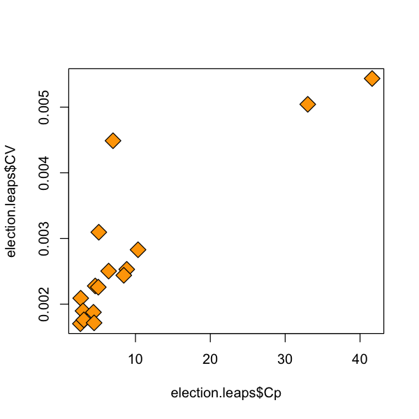

```r
plot(election.leaps$Cp, election.leaps$CV, pch=23, bg='orange', cex=2)
```

**1**

FALSE

**2**

TRUE

**3**

FALSE

**4**

FALSE

**5**

TRUE

**6**

TRUE

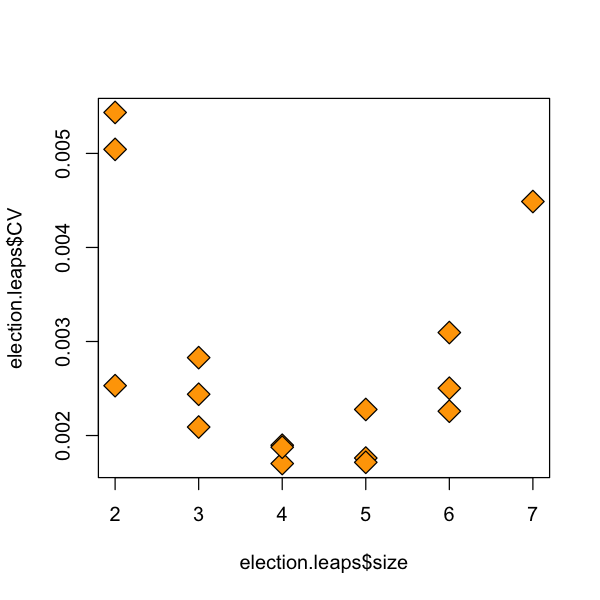

```r
plot(election.leaps$size, election.leaps$CV, pch=23, bg='orange', cex=2)
best.model.Cv = election.leaps$which[which((election.leaps$CV
                                            == min(election.leaps$CV))),]
best.model.Cv
```

## Summarizing results

The model selected depends on the criterion used.

[output not shown]

**The selected model is random and depends on which method we use!**

## Where we are so far

- Many other "criteria" have been proposed.
- Some work well for some types of data, others for different data.
- Check diagnostics!
- These criteria (except cross-validation) are not "direct measures" of predictive power, though Mallow’s $C_p$ is a step in this direction.
- $C_p$ measures the quality of a model based on both *bias* and *variance* of the model. Why is this important?
- *Bias-variance* tradeoff is ubiquitous in statistics. More soon.

## A larger example

- Resistance of $n=633$ different HIV+ viruses to drug 3TC.
- Features $p=91$ are mutations in a part of the HIV virus, response is log fold change in vitro.

```r
X_HIV = read.table('http://stats191.stanford.edu/data/NRTI_X.csv', header=FALSE, sep=',')
Y_HIV = read.table('http://stats191.stanford.edu/data/NRTI_Y.txt', header=FALSE, sep=',')
set.seed(0)
Y_HIV = as.matrix(Y_HIV)[,1]
X_HIV = as.matrix(X_HIV)
nrow(X_HIV)
```

633

## Forward stepwise

```r
D = data.frame(X_HIV, Y_HIV)
M = lm(Y_HIV ~ ., data=D)
M_forward = step(lm(Y_HIV ~ 1, data=D), list(upper=M),
                 trace=FALSE, direction='forward')
M_forward
```

```
Call:
lm(formula = Y_HIV ~ V68 + V17 + V19 + V23 + V54 + V67 + V82 +
    V32 + V81 + V87 + V57 + V41 + V31 + V29 + V30 + V70 + V39 +
    V26 + V69 + V40 + V62 + V64 + V80, data = D)

Coefficients:
(Intercept)          V68          V17          V19          V23          V54
     0.3447       4.4731       1.5777       0.3233       1.4172       0.4990
        V67          V82          V32          V81          V87          V57
     0.3796       0.3854       0.6446       0.4113       0.5646       0.1970
        V41          V31          V29          V30          V70          V39
     0.5896      -0.2111       0.5407       0.6294      -0.1591       0.4797
        V26          V69          V40          V62          V64          V80
    -0.1633       0.2094      -0.3003      -0.3095       0.1792      -0.1119
```

## Backward stepwise

```r
M_backward = step(M, list(lower= ~  1), trace=FALSE,
                  direction='backward')
M_backward
```

```
Call:
lm(formula = Y_HIV ~ V17 + V19 + V23 + V26 + V29 + V30 + V31 +
    V32 + V39 + V40 + V41 + V54 + V57 + V62 + V64 + V67 + V68 +
    V69 + V70 + V80 + V81 + V82 + V87, data = D)

Coefficients:
(Intercept)          V17          V19          V23          V26          V29
     0.3447       1.5777       0.3233       1.4172      -0.1633       0.5407
        V30          V31          V32          V39          V40          V41
     0.6294      -0.2111       0.6446       0.4797      -0.3003       0.5896
        V54          V57          V62          V64          V67          V68
     0.4990       0.1970      -0.3095       0.1792       0.3796       4.4731
        V69          V70          V80          V81          V82          V87
     0.2094      -0.1591      -0.1119       0.4113       0.3854       0.5646
```

## Both directions

```r
M_both1 = step(M, list(lower= ~  1, upper=M), trace=FALSE,
               direction='both')
M_both1
```

```
Call:
lm(formula = Y_HIV ~ V17 + V19 + V23 + V26 + V29 + V30 + V31 +
    V32 + V39 + V40 + V41 + V54 + V57 + V62 + V64 + V67 + V68 +
    V69 + V70 + V80 + V81 + V82 + V87, data = D)

Coefficients:
(Intercept)          V17          V19          V23          V26          V29
     0.3447       1.5777       0.3233       1.4172      -0.1633       0.5407
        V30          V31          V32          V39          V40          V41
     0.6294      -0.2111       0.6446       0.4797      -0.3003       0.5896
        V54          V57          V62          V64          V67          V68
     0.4990       0.1970      -0.3095       0.1792       0.3796       4.4731
        V69          V70          V80          V81          V82          V87
     0.2094      -0.1591      -0.1119       0.4113       0.3854       0.5646
```

```r
M_both2 = step(lm(Y_HIV ~ 1, data=D), list(lower= ~  1, upper=M), trace=FALSE, direction='both')
M_both2
```

```
Call:
lm(formula = Y_HIV ~ V68 + V17 + V19 + V23 + V54 + V67 + V82 +
    V32 + V81 + V87 + V57 + V41 + V31 + V29 + V30 + V70 + V39 +
    V26 + V69 + V40 + V62 + V64 + V80, data = D)

Coefficients:
(Intercept)          V68          V17          V19          V23          V54
     0.3447       4.4731       1.5777       0.3233       1.4172       0.4990
        V67          V82          V32          V81          V87          V57
     0.3796       0.3854       0.6446       0.4113       0.5646       0.1970
        V41          V31          V29          V30          V70          V39
     0.5896      -0.2111       0.5407       0.6294      -0.1591       0.4797
        V26          V69          V40          V62          V64          V80
    -0.1633       0.2094      -0.3003      -0.3095       0.1792      -0.1119
```

## Compare selected models

```r
sort(names(coef(M_forward)))
sort(names(coef(M_backward)))
sort(names(coef(M_both1)))
sort(names(coef(M_both2)))
```

1. '(Intercept)'

2. 'V17'

3. 'V19'

4. 'V23'

5. 'V26'

6. 'V29'

7. 'V30'

8. 'V31'

9. 'V32'

10. 'V39'

11. 'V40'

12. 'V41'

13. 'V54'

14. 'V57'

15. 'V62'

16. 'V64'

17. 'V67'

18. 'V68'

19. 'V69'

20. 'V70'

21. 'V80'

22. 'V81'

23. 'V82'

24. 'V87'

1. '(Intercept)'

2. 'V17'

3. 'V19'

4. 'V23'

5. 'V26'

6. 'V29'

7. 'V30'

8. 'V31'

9. 'V32'

10. 'V39'

11. 'V40'

12. 'V41'

13. 'V54'

14. 'V57'

15. 'V62'

16. 'V64'

17. 'V67'

18. 'V68'

19. 'V69'

20. 'V70'

21. 'V80'

22. 'V81'

23. 'V82'

24. 'V87'

1. '(Intercept)'

2. 'V17'

3. 'V19'

4. 'V23'

5. 'V26'

6. 'V29'

7. 'V30'

8. 'V31'

9. 'V32'

10. 'V39'

11. 'V40'

12. 'V41'

13. 'V54'

14. 'V57'

15. 'V62'

16. 'V64'

17. 'V67'

18. 'V68'

19. 'V69'

20. 'V70'

21. 'V80'

22. 'V81'

23. 'V82'

24. 'V87'

1. '(Intercept)'

2. 'V17'

3. 'V19'

4. 'V23'

5. 'V26'

6. 'V29'

7. 'V30'

8. 'V31'

9. 'V32'

10. 'V39'

11. 'V40'

12. 'V41'

13. 'V54'

14. 'V57'

15. 'V62'

16. 'V64'

17. 'V67'

18. 'V68'

19. 'V69'

20. 'V70'

21. 'V80'

22. 'V81'

23. 'V82'

24. 'V87'

## BIC vs AIC

```r
M_backward_BIC = step(M, list(lower= ~  1), trace=FALSE,
                      direction='backward', k=log(633))
M_forward_BIC = step(lm(Y_HIV ~ 1, data=D), list(upper=M), trace=FALSE,
                     direction='forward', k=log(633))
M_both1_BIC = step(M, list(upper=M, lower=~1), trace=FALSE,
                     direction='both', k=log(633))
M_both2_BIC = step(lm(Y_HIV ~ 1, data=D), list(upper=M, lower=~1), trace=FALSE,
                     direction='both', k=log(633))

sort(names(coef(M_backward_BIC)))
sort(names(coef(M_forward_BIC)))
sort(names(coef(M_both1_BIC)))
sort(names(coef(M_both2_BIC)))
```

1. '(Intercept)'

2. 'V17'

3. 'V19'

4. 'V23'

5. 'V29'

6. 'V30'

7. 'V31'

8. 'V32'

9. 'V41'

10. 'V57'

11. 'V67'

12. 'V68'

13. 'V81'

14. 'V82'

15. 'V87'

1. '(Intercept)'

2. 'V17'

3. 'V19'

4. 'V23'

5. 'V31'

6. 'V32'

7. 'V41'

8. 'V54'

9. 'V57'

10. 'V67'

11. 'V68'

12. 'V81'

13. 'V82'

14. 'V87'

1. '(Intercept)'

2. 'V17'

3. 'V19'

4. 'V23'

5. 'V29'

6. 'V30'

7. 'V31'

8. 'V32'

9. 'V41'

10. 'V57'

11. 'V67'

12. 'V68'

13. 'V81'

14. 'V82'

15. 'V87'

1. '(Intercept)'

2. 'V17'

3. 'V19'

4. 'V23'

5. 'V31'

6. 'V32'

7. 'V41'

8. 'V54'

9. 'V57'

10. 'V67'

11. 'V68'

12. 'V81'

13. 'V82'

14. 'V87'

## Inference after selection: data snooping and splitting

Each of the above criteria return a model. The `summary` provides $p$-values.

```r
summary(election.step.forward)
```

```
Call:
lm(formula = V ~ D + P, data = election.table)

Residuals:
      Min        1Q    Median        3Q       Max
-0.101121 -0.036838 -0.006987  0.019029  0.163250

Coefficients:
             Estimate Std. Error t value Pr(>|t|)
(Intercept)  0.514022   0.022793  22.552  1.2e-14 ***
D            0.043134   0.017381   2.482   0.0232 *
P           -0.006017   0.003891  -1.546   0.1394
---
Signif. codes:  0 ‘***’ 0.001 ‘**’ 0.01 ‘*’ 0.05 ‘.’ 0.1 ‘ ’ 1

Residual standard error: 0.06442 on 18 degrees of freedom
Multiple R-squared:  0.3372,	Adjusted R-squared:  0.2636
F-statistic: 4.579 on 2 and 18 DF,  p-value: 0.02468
```

We can also form confidence intervals. **But, can we trust these intervals or tests? No!**

```r
confint(election.step.forward)
```

|  | 2.5 % | 97.5 % |
| --- | --- | --- |
| (Intercept) | 0.466136288 | 0.561907650 |
| D | 0.006618001 | 0.079649847 |
| P | -0.014193177 | 0.002158189 |

## How bad could it really be?

To illustrate the "dangers" of trusting the above $p$-values, I will use the `selectiveInference` package which has a variant of forward stepwise.

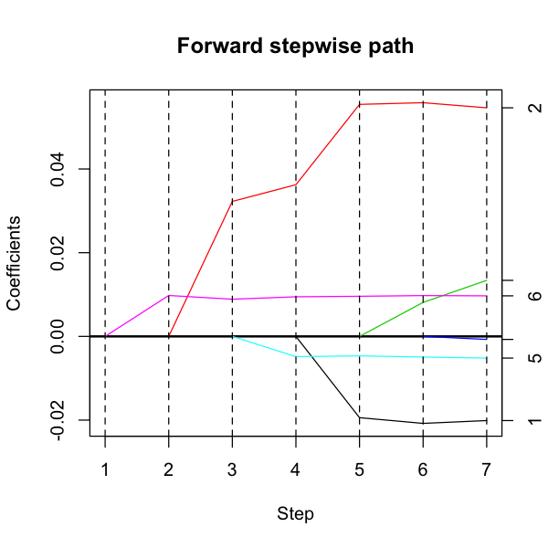

```r
library(selectiveInference)
plot(fs(X, V))
```

```r
fsInf(fs(X, V))
```

```
Call:
fsInf(obj = fs(X, V))

Standard deviation of noise (specified or estimated) sigma = 0.041

Sequential testing results with alpha = 0.100
 Step Var   Coef Z-score P-value LowConfPt UpConfPt LowTailArea UpTailArea
    1   6  0.010   6.386   0.000     0.007    0.012       0.048      0.048
    2   2  0.032   2.855   0.016     0.008    0.053       0.049      0.050
    3   5 -0.005  -1.430   0.781    -0.008    0.070       0.049      0.050
    4   1 -0.019  -1.240   0.065    -0.382    0.007       0.050      0.049
    5   3  0.008   0.266   0.826    -0.477    0.053       0.050      0.050
    6   4 -0.001  -0.180   0.693    -0.025    0.066       0.050      0.050

Estimated stopping point from ForwardStop rule = 2
```

Let's generate data for which we know all coefficients are zero and look at the $p$-values.

We will look at the *naive* p-values which ignore selection, as well as a certain kind of corrected $p$-values from `selectiveInference`.

```r
X_fake = matrix(rnorm(4000), 100, 40)
nsim = 1000
naiveP = c()
for (i in 1:nsim) {
    Z = rnorm(nrow(X_fake))
    fsfit = fs(X_fake, Z, maxsteps=1)
    fsinf = fsInf(fsfit, sigma=1)
    naive.lm = lm(Z ~ X_fake[,fsinf$vars[1]])
    naiveP = c(naiveP, summary(naive.lm)$coef[2,4])
}
```

What is the type I error of the naive test?

```r
ecdf(naiveP)(0.05)
```

0.878

## Data splitting

- A simple fix for this problem is to randomly split the data into two groups (often but not always of equal size).
- This gives valid inference under some assumptions.
- Which variable is chosen is random as it depends on the split. *Selected model might not be as "good".*
- Also, we have access to less data to form confidence intervals ($\implies$ wider), test hypotheses ($\implies$ less power).

## When is data splitting OK?

- Just as when we did not select a model, when computing $p$-values and confidence intervals we use a model.
- If we are happy with these assumptions for a model selected from the data, then data splitting is OK.

```r
splitP = c()
for (i in 1:nsim) {
    Z = rnorm(nrow(X_fake))
    subset_s = sample(1:nrow(X_fake), nrow(X_fake)/2, replace=FALSE)
    #_s for selection
    subset_i = rep(TRUE, nrow(X_fake)) # _i for inference
    subset_i[subset_s] = FALSE

    # Step 1: choose your model
    fsfit = fs(X_fake[subset_s,], Z[subset_s], maxsteps=1)

    # Step 2: compute p-values
    split.lm = lm(Z ~ X_fake[,fsinf$vars[1]], subset=subset_i)
    splitP = c(splitP, summary(split.lm)$coef[2,4])
}
```

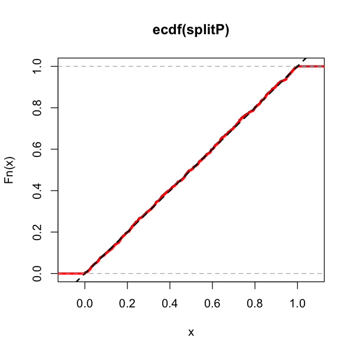

```r
plot(ecdf(splitP), lwd=3, col='red')
abline(0,1, lwd=2, lty=2)
```

It turns out that it is possible to modify the usual $t$-statistic so that we still get valid tests after the first step. Its description is a little beyond the level of this course.

```r
exactP = c()
for (i in 1:nsim) {
    Z = rnorm(nrow(X_fake))
    fsfit = fs(X_fake, Z, maxsteps=1)
    fsinf = fsInf(fsfit, sigma=1)
    exactP = c(exactP, fsinf$pv[1])
}
```

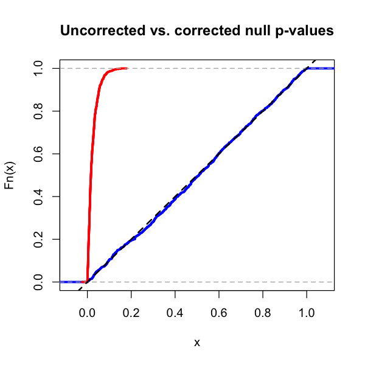

```r
plot(ecdf(exactP), lwd=3, col='blue', main='Uncorrected vs. corrected null p-values')
plot(ecdf(naiveP), lwd=3, col='red', add=TRUE)
abline(0,1, lwd=2, lty=2)
```

## Power

- Both the exact and data splitting give valid p-values.
- Which is more powerful?
- Let's put some signal in and see.
- **Note, we can't be sure we are selecting the "right" variable each time so model might not be "correct". But this can happen even when we write down a model without looking at the data.**

```r
exactP_A = c()
splitP_A = c()
correct_model = c()

beta1 = .3 # signal size

for (i in 1:nsim) {
    Z = rnorm(nrow(X_fake)) + X_fake[,1] * beta1
    fsfit = fs(X_fake, Z, maxsteps=1)
    fsinf = fsInf(fsfit, sigma=1)
    exactP_A = c(exactP_A, fsinf$pv[1])

    correct_model = c(correct_model, fsinf$vars[1] == 1)

    # data splitting pvalue

    subset = sample(1:nrow(X_fake), nrow(X_fake)/2, replace=FALSE)
    subset_c = rep(TRUE, nrow(X_fake))
    subset_c[subset] = FALSE
    fsfit = fs(X_fake[subset,], Z[subset], maxsteps=1)
    split.lm = lm(Z ~ X_fake[,fsinf$vars[1]], subset=subset_c)
    splitP_A = c(splitP_A, summary(split.lm)$coef[2,4])

}
```

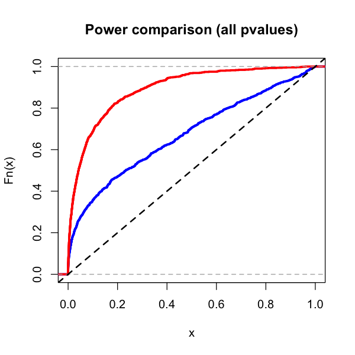

```r
plot(ecdf(exactP_A), lwd=3, col='blue', xlim=c(0,1), main='Power comparison (all pvalues)')
plot(ecdf(splitP_A), lwd=3, col='red', add=TRUE)
abline(0,1, lwd=2, lty=2)
```

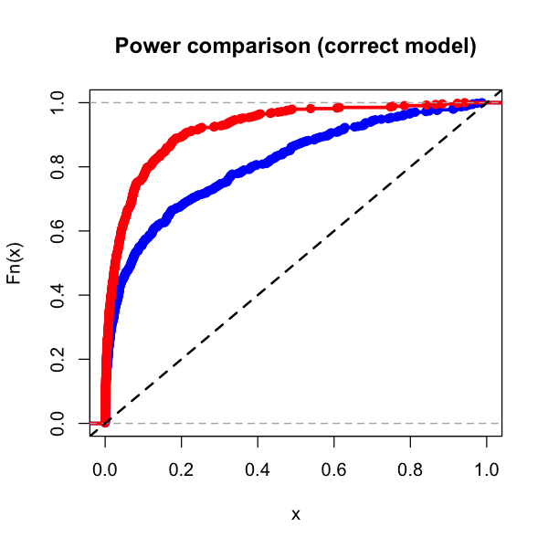

```r
plot(ecdf(exactP_A[correct_model]), lwd=3, col='blue', xlim=c(0,1),
     main='Power comparison (correct model)')
plot(ecdf(splitP_A[correct_model]), lwd=3, col='red', add=TRUE)
abline(0,1, lwd=2, lty=2)
```

## Confidence intervals

- Which has shorter confidence intervals?

```r
exactL = c()
splitL = c()
correct_model = c()

beta1 = 0.3
for (i in 1:nsim) {
    Z = rnorm(nrow(X_fake)) + X_fake[,1] * beta1
    fsfit = fs(X_fake, Z, maxsteps=1)
    fsinf = fsInf(fsfit, sigma=1)
    exactL = c(exactL, fsinf$ci[1,2] - fsinf$ci[1,1])

    correct_model = c(correct_model, fsinf$vars[1] == 1)

    # data splitting pvalue

    subset = sample(1:nrow(X_fake), nrow(X_fake)/2, replace=FALSE)
    subset_c = rep(TRUE, nrow(X)) #_c for confirmatory
    subset_c[subset] = FALSE
    fsfit = fs(X_fake[subset,], Z[subset], maxsteps=1)
    split.lm = lm(Z ~ X_fake[,fsinf$vars[1]], subset=subset_c)
    conf = confint(split.lm, level=0.9)
    splitL = c(splitL, conf[2,2] - conf[2,1])

}
```

```r
data.frame(median(exactL), median(splitL))
```

| median.exactL. | median.splitL. |
| --- | --- |
| 0.8226825 | 1.159897 |

```r
data.frame(median(exactL[correct_model]), median(splitL[correct_model]))
```

| median.exactL.correct_model.. | median.splitL.correct_model.. |
| --- | --- |
| 0.607412 | 1.211622 |

### An exciting area of research

This `exactP` was only discovered [recently](http://amstat.tandfonline.com/doi/abs/10.1080/01621459.2015.1108848)!

For a long time, I have been saying things along the lines of

```
Inference after model selection
is basically out the window.

Forget all we taught you about t and
F distributions as it is no longer true...

Use data splitting!
```

It turns out that inference after selection is possible, and it doesn't force us to throw away all of our tools for inference.

*But, it is a little more complicated to describe.*